# GitHub - parte 2

Residencia de Epidemiología

## Colaboración

- El uso de Git/GitHub nos permite invitar colaboradores a nuestros repositorios que van a tener permiso de edición.
- Terminológicamente hay un *“dueño/a”* del repositorio y un *“colaborador/a”* invitado/a (puede haber más de uno/a)
- Todos/as tienen que tener cuenta en GitHub y el equipo donde van a trabajar configurado con Git.

## Colaboración

- El usuario o usuaria *“dueño/a”* del repositorio debe ingresar a la opción **Settings**

[figure not shown]

## Colaboración

- Luego a la opción **Collaborators**

[figure not shown]

## Colaboración

- Visualizaremos una página con información sobre el repositorio (si es público o privado) y cuantas personas (además del *“dueño/a”*) tienen acceso.
- También encontraremos un botón verde con la leyenda **Add people** que se utiliza para invitar colaboradores.

[figure not shown]

## Colaboración

- En el cuadro de búsqueda de la ventana emergente debemos escribir el nombre de usuario/a, el nombre completo o el mail de la persona que queremos invitar como colaborador/a.
- Si existe en GitHub, aparecerá debajo para seleccionar e invitar.

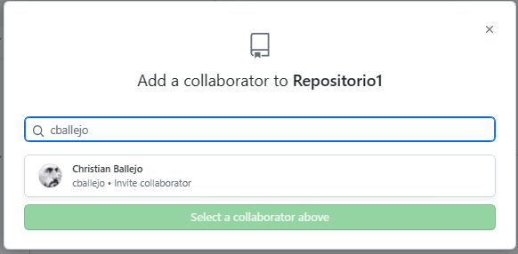

## Colaboración

- El mensaje con la invitación va a llegar al mail del/a colaborador/a.
- En el área de administración de accesos, el/a usuario/a invitado/a figura como “Inivitación pendiente” hasta que la acepte.

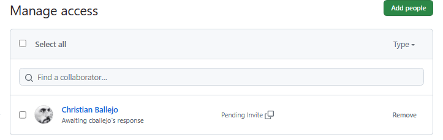

## Colaboración

- En el mail del/a usuario/a invitado/a llegará un mensaje similar a este:

[figure not shown]

- Podemos pulsar sobre el botón **View invitation** para aceptar. El mensaje expira en 7 días.

## Colaboración

- Al pulsar en el botón, nos abre el navegador y nos lleva al sitio de GitHub, donde previamente logueados, debemos aceptar. (botón **Accept invitation**)

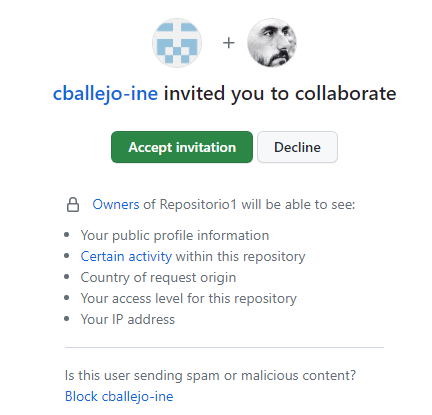

## Colaboración

- Al aceptar visualizaremos el repositorio en cuestión y podremos leer una leyenda que dice que podemos *hacer **push*** en ese repositorio.

[figure not shown]

## Colaboración

- Ahora debemos abrir el cuadro de diálogo de **Code** y copiar la dirección del repositorio.

[figure not shown]

## Colaboración

- A continuación vamos al RStudio y creamos un nuevo proyecto desde **Version Control -> Git** y pegamos la URL copiada

[figure not shown]

- A partir de aquí, el repositorio se descarga con la ultima versión actualizada existente en GitHub.

## Colaboración

- Cualquier cambio que realicemos en los archivos podemos subirlos haciendole **commit** y **push**. Estos cambios se podrán ver desde el mismo GitHub, dentro del repositorio del/a *dueño/a*.

[figure not shown]

## Colaboración

Juguemos entre nosotros/as:

- Construyamos un *repositorio* en nuestro **GitHub.**
- Vinculemos el repositorio nuevo con un nuevo proyecto desde *RStudio -> New Project -> Version Control -> Git*
- Invitemos a **colaborar** a un compañer/a
- Sigamos el paso a paso anterior para poder compartir y modificar archivos de GitHub, donde seamos **dueños/as** y *colaboradores/as* de otros/as.

## GitHub Pages

Las GitHub Pages son páginas web públicas que se publican a través de GitHub.

- Sirven para mostrar resultados de proyectos de código abierto, hospedar material educativo, blogs o incluso compartir el CV.
- El nombre del sitio desde donde se publican las páginas tiene el formato `nombre_de_usuario.github.io` (por ejemplo, estas mismas diapositivas están alojadas en cballejo.github.io)
- Normalmente la forma de visualizar una página nos exige construir archivos de marcas tipo HTML o md (Markdown), es decir, proyectos donde tengamos Rmarkdown y/o Quarto.

## GitHub Pages

Vamos a publicar el contenido perteneciente a un proyecto que van a clonar de manera especial e independiente (**fork**).

Un **fork** es una copia de un repositorio pero creado en tu propia cuenta de GitHub, donde vivirá en un espacio diferente al original y podrá evolucionar de manera distinta.

[figure not shown]

## GitHub Pages

En el usuario *cballejo* de GitHub van a encontrar un repositorio denominado **Prueba_web**. Vamos a hacer un fork de ese repositorio.

[figure not shown]

## GitHub Pages

El repositorio nos advierte que está “bifurcado” del original cballejo/Prueba_web (forked)

[figure not shown]

## GitHub Pages

Luego, desde el fork del repositorio en nuestra cuenta, vamos a copiar la URL para crear un proyecto local que conecte con el repositorio.

[figure not shown]

## GitHub Pages

Desde el RStudio de nuestro equipo creamos un nuevo proyecto a partir del camino *RStudio -> New Project -> Version Control -> Git*, pegando la URL copiada.

[figure not shown]

## GitHub Pages

Una vez descargado el repositorio en el proyecto local, abrimos el archivo **Ejemplo_web.Rmd** y lo modificamos, editando el *nombre del autor* en la cabecera YAML del mismo y finalmente guardamos.

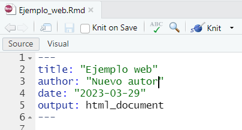

Tejemos el archivo *Rmarkdown* desde el **botón Knitr** para producir un HTML con la modificación que realizamos anteriormente.

## GitHub Pages

Seleccionamos los archivos modificados que aparecen en la pestaña Git (**Ejemplo_web.Rmd** y **Ejemplo_web.html**) para hacer un **commit** y luego **Push** (subimos el cambio al GitHub)

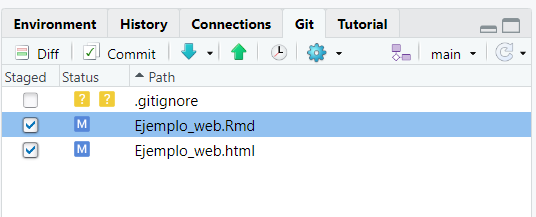

## GitHub Pages

Finalmente, desde el sitio GitHub vamos a activar las **Pages GitHub** del repositorio. Para esto, estando dentro del repositorio **Prueba_web** pulsamos sobre la **opción Settings** y luego el menú **Pages**.

[figure not shown]

Seleccionamos la opción **main** en *Branch*, dejamos la ruta **/(root)** y pulsamos el **botón Save**.

## GitHub Pages

A continuación abrimos en un navegador la siguiente dirección: `<<usuario>>.github.io/Prueba_web/Ejemplo_web.html` , para visualizar lo publicado.

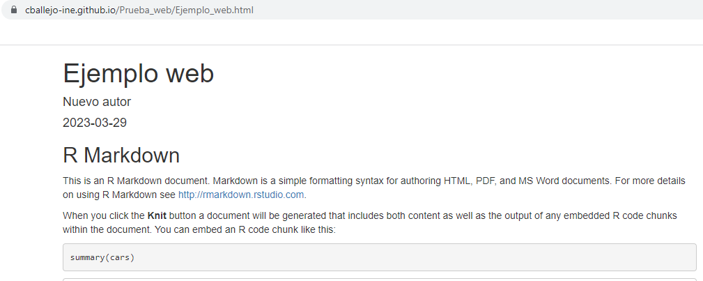